# Risk Factor Analysis

## Outcome Variable

**Outcome Variable:** stunted

## Predictor Variables

**Intervention Variable:** perdiar6

**Adjustment Set:**

unadjusted

## Stratifying Variables

The analysis was stratified on these variable(s):

- agecat
- studyid
- country

## Data Summary

| agecat | studyid | country | perdiar6 | stunted | n_cell | n |
| --- | --- | --- | --- | --- | --- | --- |
| Birth | ki0047075b-MAL-ED | BANGLADESH | (0%, 5%] | 0 | 83 | 257 |
| Birth | ki0047075b-MAL-ED | BANGLADESH | (0%, 5%] | 1 | 13 | 257 |
| Birth | ki0047075b-MAL-ED | BANGLADESH | 0% | 0 | 71 | 257 |
| Birth | ki0047075b-MAL-ED | BANGLADESH | 0% | 1 | 15 | 257 |
| Birth | ki0047075b-MAL-ED | BANGLADESH | >5% | 0 | 56 | 257 |
| Birth | ki0047075b-MAL-ED | BANGLADESH | >5% | 1 | 19 | 257 |
| Birth | ki0047075b-MAL-ED | BRAZIL | (0%, 5%] | 0 | 12 | 191 |
| Birth | ki0047075b-MAL-ED | BRAZIL | (0%, 5%] | 1 | 1 | 191 |
| Birth | ki0047075b-MAL-ED | BRAZIL | 0% | 0 | 156 | 191 |
| Birth | ki0047075b-MAL-ED | BRAZIL | 0% | 1 | 20 | 191 |
| Birth | ki0047075b-MAL-ED | BRAZIL | >5% | 0 | 2 | 191 |
| Birth | ki0047075b-MAL-ED | BRAZIL | >5% | 1 | 0 | 191 |
| Birth | ki0047075b-MAL-ED | INDIA | (0%, 5%] | 0 | 90 | 206 |
| Birth | ki0047075b-MAL-ED | INDIA | (0%, 5%] | 1 | 19 | 206 |
| Birth | ki0047075b-MAL-ED | INDIA | 0% | 0 | 37 | 206 |
| Birth | ki0047075b-MAL-ED | INDIA | 0% | 1 | 10 | 206 |
| Birth | ki0047075b-MAL-ED | INDIA | >5% | 0 | 46 | 206 |
| Birth | ki0047075b-MAL-ED | INDIA | >5% | 1 | 4 | 206 |
| Birth | ki0047075b-MAL-ED | NEPAL | (0%, 5%] | 0 | 53 | 173 |
| Birth | ki0047075b-MAL-ED | NEPAL | (0%, 5%] | 1 | 4 | 173 |
| Birth | ki0047075b-MAL-ED | NEPAL | 0% | 0 | 55 | 173 |
| Birth | ki0047075b-MAL-ED | NEPAL | 0% | 1 | 5 | 173 |
| Birth | ki0047075b-MAL-ED | NEPAL | >5% | 0 | 47 | 173 |
| Birth | ki0047075b-MAL-ED | NEPAL | >5% | 1 | 9 | 173 |
| Birth | ki0047075b-MAL-ED | PERU | (0%, 5%] | 0 | 76 | 287 |
| Birth | ki0047075b-MAL-ED | PERU | (0%, 5%] | 1 | 12 | 287 |
| Birth | ki0047075b-MAL-ED | PERU | 0% | 0 | 71 | 287 |
| Birth | ki0047075b-MAL-ED | PERU | 0% | 1 | 12 | 287 |
| Birth | ki0047075b-MAL-ED | PERU | >5% | 0 | 106 | 287 |
| Birth | ki0047075b-MAL-ED | PERU | >5% | 1 | 10 | 287 |

[output cut: 234 more lines]

The following strata were considered:

- agecat: 24 months, studyid: ki0047075b-MAL-ED, country: BANGLADESH
- agecat: 24 months, studyid: ki0047075b-MAL-ED, country: BRAZIL
- agecat: 24 months, studyid: ki0047075b-MAL-ED, country: INDIA
- agecat: 24 months, studyid: ki0047075b-MAL-ED, country: NEPAL
- agecat: 24 months, studyid: ki0047075b-MAL-ED, country: PERU
- agecat: 24 months, studyid: ki0047075b-MAL-ED, country: SOUTH AFRICA
- agecat: 24 months, studyid: ki0047075b-MAL-ED, country: TANZANIA, UNITED REPUBLIC OF
- agecat: 24 months, studyid: ki1017093-NIH-Birth, country: BANGLADESH
- agecat: 24 months, studyid: ki1017093b-PROVIDE, country: BANGLADESH
- agecat: 24 months, studyid: ki1017093c-NIH-Crypto, country: BANGLADESH
- agecat: 24 months, studyid: ki1114097-CMIN, country: BANGLADESH
- agecat: 24 months, studyid: ki1114097-CMIN, country: GUINEA-BISSAU
- agecat: 24 months, studyid: ki1114097-CMIN, country: PERU
- agecat: 24 months, studyid: ki1114097-CONTENT, country: PERU
- agecat: 6 months, studyid: ki0047075b-MAL-ED, country: BANGLADESH
- agecat: 6 months, studyid: ki0047075b-MAL-ED, country: BRAZIL
- agecat: 6 months, studyid: ki0047075b-MAL-ED, country: INDIA
- agecat: 6 months, studyid: ki0047075b-MAL-ED, country: NEPAL
- agecat: 6 months, studyid: ki0047075b-MAL-ED, country: PERU
- agecat: 6 months, studyid: ki0047075b-MAL-ED, country: SOUTH AFRICA
- agecat: 6 months, studyid: ki0047075b-MAL-ED, country: TANZANIA, UNITED REPUBLIC OF
- agecat: 6 months, studyid: ki1000109-ResPak, country: PAKISTAN
- agecat: 6 months, studyid: ki1017093-NIH-Birth, country: BANGLADESH
- agecat: 6 months, studyid: ki1017093b-PROVIDE, country: BANGLADESH
- agecat: 6 months, studyid: ki1017093c-NIH-Crypto, country: BANGLADESH
- agecat: 6 months, studyid: ki1114097-CMIN, country: BANGLADESH
- agecat: 6 months, studyid: ki1114097-CMIN, country: BRAZIL
- agecat: 6 months, studyid: ki1114097-CMIN, country: GUINEA-BISSAU
- agecat: 6 months, studyid: ki1114097-CMIN, country: PERU
- agecat: 6 months, studyid: ki1114097-CONTENT, country: PERU
- agecat: Birth, studyid: ki0047075b-MAL-ED, country: BANGLADESH
- agecat: Birth, studyid: ki0047075b-MAL-ED, country: BRAZIL
- agecat: Birth, studyid: ki0047075b-MAL-ED, country: INDIA
- agecat: Birth, studyid: ki0047075b-MAL-ED, country: NEPAL
- agecat: Birth, studyid: ki0047075b-MAL-ED, country: PERU
- agecat: Birth, studyid: ki0047075b-MAL-ED, country: SOUTH AFRICA
- agecat: Birth, studyid: ki0047075b-MAL-ED, country: TANZANIA, UNITED REPUBLIC OF
- agecat: Birth, studyid: ki1000109-ResPak, country: PAKISTAN
- agecat: Birth, studyid: ki1017093-NIH-Birth, country: BANGLADESH
- agecat: Birth, studyid: ki1017093c-NIH-Crypto, country: BANGLADESH
- agecat: Birth, studyid: ki1114097-CMIN, country: BANGLADESH
- agecat: Birth, studyid: ki1114097-CMIN, country: BRAZIL
- agecat: Birth, studyid: ki1114097-CMIN, country: PERU
- agecat: Birth, studyid: ki1114097-CONTENT, country: PERU

### Dropped Strata

Some strata were dropped due to rare outcomes:

- agecat: Birth, studyid: ki0047075b-MAL-ED, country: BRAZIL
- agecat: Birth, studyid: ki0047075b-MAL-ED, country: INDIA
- agecat: Birth, studyid: ki0047075b-MAL-ED, country: NEPAL
- agecat: Birth, studyid: ki0047075b-MAL-ED, country: SOUTH AFRICA
- agecat: Birth, studyid: ki0047075b-MAL-ED, country: TANZANIA, UNITED REPUBLIC OF
- agecat: Birth, studyid: ki1000109-ResPak, country: PAKISTAN
- agecat: Birth, studyid: ki1017093-NIH-Birth, country: BANGLADESH
- agecat: Birth, studyid: ki1017093c-NIH-Crypto, country: BANGLADESH
- agecat: Birth, studyid: ki1114097-CMIN, country: BANGLADESH
- agecat: Birth, studyid: ki1114097-CMIN, country: BRAZIL
- agecat: Birth, studyid: ki1114097-CMIN, country: PERU
- agecat: Birth, studyid: ki1114097-CONTENT, country: PERU
- agecat: 6 months, studyid: ki0047075b-MAL-ED, country: BRAZIL
- agecat: 6 months, studyid: ki0047075b-MAL-ED, country: NEPAL
- agecat: 6 months, studyid: ki0047075b-MAL-ED, country: SOUTH AFRICA
- agecat: 6 months, studyid: ki1114097-CMIN, country: BRAZIL
- agecat: 6 months, studyid: ki1114097-CONTENT, country: PERU
- agecat: 24 months, studyid: ki0047075b-MAL-ED, country: BRAZIL
- agecat: 24 months, studyid: ki0047075b-MAL-ED, country: SOUTH AFRICA
- agecat: 24 months, studyid: ki1114097-CONTENT, country: PERU

## Methods Detail

We’re interested in the causal parameters $E[Y_a]$ for all values of $a \in \mathcal{A}$. These parameters represent the mean outcome if, possibly contrary to fact, we intervened to set all units to have $A=a$. Under the randomization and positivity assumptions, these are identified by the statistical parameters $\psi_a=E_W[E_{Y|A,W}(Y|A=a,W)]$. In addition, we’re interested in the mean of $Y$, $E[Y]$ under no intervention (the observed mean). We will estimate these parameters by using SuperLearner to fit the relevant likelihood factors – $E_{Y|A,W}(Y|A=a,W)$ and $p(A=a|W)$, and then updating our likelihood fit using a joint TMLE.

For unadjusted analyses ($W=\{\}$), initial likelihoods were estimated using Lrnr_glm to estimate the simple $E(Y|A)$ and Lrnr_mean to estimate $p(A)$. For adjusted analyses, a small library containing Lrnr_glmnet, Lrnr_xgboost, and Lrnr_mean was used.

Having estimated these parameters, we will then use the delta method to estimate relative risks and attributable risks relative to a prespecified baseline level of $A$.

# Results Detail

## Results Plots

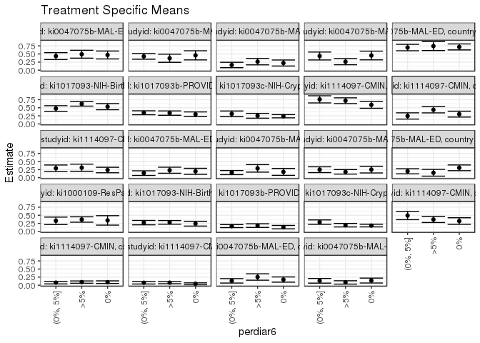

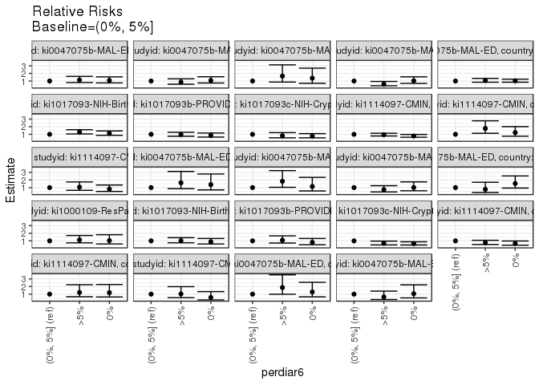

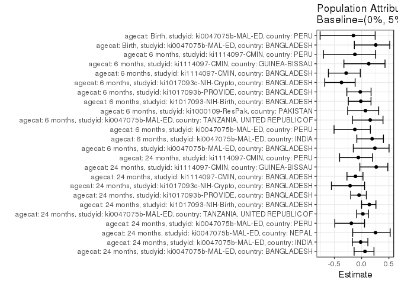

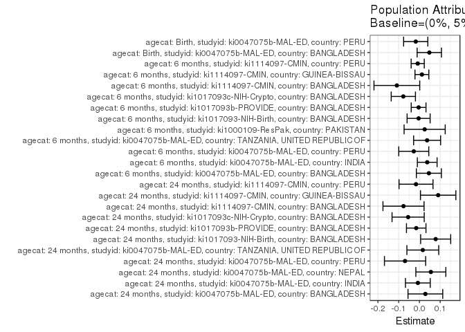

## Results Table

### Parameter: TSM

| agecat | studyid | country | intervention_level | baseline_level | estimate | ci_lower | ci_upper |
| --- | --- | --- | --- | --- | --- | --- | --- |
| Birth | ki0047075b-MAL-ED | BANGLADESH | (0%, 5%] | NA | 0.1354167 | 0.0668365 | 0.2039968 |
| Birth | ki0047075b-MAL-ED | BANGLADESH | 0% | NA | 0.1744186 | 0.0940620 | 0.2547752 |
| Birth | ki0047075b-MAL-ED | BANGLADESH | >5% | NA | 0.2533333 | 0.1547114 | 0.3519553 |
| Birth | ki0047075b-MAL-ED | PERU | (0%, 5%] | NA | 0.1363636 | 0.0645380 | 0.2081893 |
| Birth | ki0047075b-MAL-ED | PERU | 0% | NA | 0.1445783 | 0.0687889 | 0.2203678 |
| Birth | ki0047075b-MAL-ED | PERU | >5% | NA | 0.0862069 | 0.0350420 | 0.1373718 |
| 6 months | ki0047075b-MAL-ED | BANGLADESH | (0%, 5%] | NA | 0.1413043 | 0.0699773 | 0.2126314 |
| 6 months | ki0047075b-MAL-ED | BANGLADESH | 0% | NA | 0.1971831 | 0.1044436 | 0.2899226 |
| 6 months | ki0047075b-MAL-ED | BANGLADESH | >5% | NA | 0.2307692 | 0.1370732 | 0.3244652 |
| 6 months | ki0047075b-MAL-ED | INDIA | (0%, 5%] | NA | 0.1574803 | 0.0939953 | 0.2209654 |
| 6 months | ki0047075b-MAL-ED | INDIA | 0% | NA | 0.1800000 | 0.0732843 | 0.2867157 |
| 6 months | ki0047075b-MAL-ED | INDIA | >5% | NA | 0.2881356 | 0.1723269 | 0.4039443 |
| 6 months | ki0047075b-MAL-ED | PERU | (0%, 5%] | NA | 0.2471910 | 0.1574050 | 0.3369770 |
| 6 months | ki0047075b-MAL-ED | PERU | 0% | NA | 0.2500000 | 0.1468923 | 0.3531077 |
| 6 months | ki0047075b-MAL-ED | PERU | >5% | NA | 0.1810345 | 0.1108357 | 0.2512332 |
| 6 months | ki0047075b-MAL-ED | TANZANIA, UNITED REPUBLIC OF | (0%, 5%] | NA | 0.1979167 | 0.1180539 | 0.2777794 |
| 6 months | ki0047075b-MAL-ED | TANZANIA, UNITED REPUBLIC OF | 0% | NA | 0.3047619 | 0.2165390 | 0.3929848 |
| 6 months | ki0047075b-MAL-ED | TANZANIA, UNITED REPUBLIC OF | >5% | NA | 0.1521739 | 0.0481643 | 0.2561836 |
| 6 months | ki1000109-ResPak | PAKISTAN | (0%, 5%] | NA | 0.3281250 | 0.2128466 | 0.4434034 |
| 6 months | ki1000109-ResPak | PAKISTAN | 0% | NA | 0.3414634 | 0.1960032 | 0.4869236 |
| 6 months | ki1000109-ResPak | PAKISTAN | >5% | NA | 0.3692308 | 0.2860953 | 0.4523663 |
| 6 months | ki1017093-NIH-Birth | BANGLADESH | (0%, 5%] | NA | 0.2721893 | 0.2050226 | 0.3393561 |
| 6 months | ki1017093-NIH-Birth | BANGLADESH | 0% | NA | 0.2403101 | 0.1665091 | 0.3141111 |
| 6 months | ki1017093-NIH-Birth | BANGLADESH | >5% | NA | 0.2803347 | 0.2233370 | 0.3373325 |
| 6 months | ki1017093b-PROVIDE | BANGLADESH | (0%, 5%] | NA | 0.1652893 | 0.1184507 | 0.2121278 |
| 6 months | ki1017093b-PROVIDE | BANGLADESH | 0% | NA | 0.1329114 | 0.0799322 | 0.1858906 |
| 6 months | ki1017093b-PROVIDE | BANGLADESH | >5% | NA | 0.1803279 | 0.1245776 | 0.2360781 |
| 6 months | ki1017093c-NIH-Crypto | BANGLADESH | (0%, 5%] | NA | 0.2874251 | 0.2187386 | 0.3561117 |
| 6 months | ki1017093c-NIH-Crypto | BANGLADESH | 0% | NA | 0.1818182 | 0.1408527 | 0.2227837 |
| 6 months | ki1017093c-NIH-Crypto | BANGLADESH | >5% | NA | 0.1932367 | 0.1394116 | 0.2470618 |
| 6 months | ki1114097-CMIN | BANGLADESH | (0%, 5%] | NA | 0.4915254 | 0.3636977 | 0.6193532 |
| 6 months | ki1114097-CMIN | BANGLADESH | 0% | NA | 0.3209877 | 0.2191088 | 0.4228665 |
| 6 months | ki1114097-CMIN | BANGLADESH | >5% | NA | 0.3689320 | 0.2755558 | 0.4623082 |
| 6 months | ki1114097-CMIN | GUINEA-BISSAU | (0%, 5%] | NA | 0.0789474 | 0.0405761 | 0.1173186 |
| 6 months | ki1114097-CMIN | GUINEA-BISSAU | 0% | NA | 0.0943396 | 0.0549635 | 0.1337158 |
| 6 months | ki1114097-CMIN | GUINEA-BISSAU | >5% | NA | 0.0962963 | 0.0610829 | 0.1315097 |
| 6 months | ki1114097-CMIN | PERU | (0%, 5%] | NA | 0.0760870 | 0.0377470 | 0.1144270 |
| 6 months | ki1114097-CMIN | PERU | 0% | NA | 0.0434783 | 0.0139889 | 0.0729676 |
| 6 months | ki1114097-CMIN | PERU | >5% | NA | 0.0786517 | 0.0463369 | 0.1109664 |
| 24 months | ki0047075b-MAL-ED | BANGLADESH | (0%, 5%] | NA | 0.4337349 | 0.3268644 | 0.5406054 |
| 24 months | ki0047075b-MAL-ED | BANGLADESH | 0% | NA | 0.4687500 | 0.3462024 | 0.5912976 |
| 24 months | ki0047075b-MAL-ED | BANGLADESH | >5% | NA | 0.4923077 | 0.3704826 | 0.6141328 |
| 24 months | ki0047075b-MAL-ED | INDIA | (0%, 5%] | NA | 0.4262295 | 0.3382832 | 0.5141758 |
| 24 months | ki0047075b-MAL-ED | INDIA | 0% | NA | 0.4583333 | 0.3170656 | 0.5996011 |
| 24 months | ki0047075b-MAL-ED | INDIA | >5% | NA | 0.3684211 | 0.2429177 | 0.4939244 |
| 24 months | ki0047075b-MAL-ED | NEPAL | (0%, 5%] | NA | 0.1600000 | 0.0768482 | 0.2431518 |
| 24 months | ki0047075b-MAL-ED | NEPAL | 0% | NA | 0.2207792 | 0.1279325 | 0.3136259 |
| 24 months | ki0047075b-MAL-ED | NEPAL | >5% | NA | 0.2631579 | 0.1639397 | 0.3623761 |
| 24 months | ki0047075b-MAL-ED | PERU | (0%, 5%] | NA | 0.4375000 | 0.3156596 | 0.5593404 |
| 24 months | ki0047075b-MAL-ED | PERU | 0% | NA | 0.4528302 | 0.3184851 | 0.5871753 |
| 24 months | ki0047075b-MAL-ED | PERU | >5% | NA | 0.2619048 | 0.1676465 | 0.3561630 |
| 24 months | ki0047075b-MAL-ED | TANZANIA, UNITED REPUBLIC OF | (0%, 5%] | NA | 0.6987952 | 0.5998643 | 0.7977261 |
| 24 months | ki0047075b-MAL-ED | TANZANIA, UNITED REPUBLIC OF | 0% | NA | 0.7173913 | 0.6251677 | 0.8096149 |
| 24 months | ki0047075b-MAL-ED | TANZANIA, UNITED REPUBLIC OF | >5% | NA | 0.7435897 | 0.6062275 | 0.8809520 |
| 24 months | ki1017093-NIH-Birth | BANGLADESH | (0%, 5%] | NA | 0.4765625 | 0.3899377 | 0.5631873 |
| 24 months | ki1017093-NIH-Birth | BANGLADESH | 0% | NA | 0.5327103 | 0.4380644 | 0.6273561 |
| 24 months | ki1017093-NIH-Birth | BANGLADESH | >5% | NA | 0.6185567 | 0.5501248 | 0.6869886 |
| 24 months | ki1017093b-PROVIDE | BANGLADESH | (0%, 5%] | NA | 0.3448276 | 0.2836123 | 0.4060428 |
| 24 months | ki1017093b-PROVIDE | BANGLADESH | 0% | NA | 0.2980132 | 0.2249972 | 0.3710293 |
| 24 months | ki1017093b-PROVIDE | BANGLADESH | >5% | NA | 0.3350515 | 0.2685742 | 0.4015289 |
| 24 months | ki1017093c-NIH-Crypto | BANGLADESH | (0%, 5%] | NA | 0.3113208 | 0.2230879 | 0.3995537 |
| 24 months | ki1017093c-NIH-Crypto | BANGLADESH | 0% | NA | 0.2382671 | 0.1880486 | 0.2884857 |
| 24 months | ki1017093c-NIH-Crypto | BANGLADESH | >5% | NA | 0.2519084 | 0.1774979 | 0.3263189 |
| 24 months | ki1114097-CMIN | BANGLADESH | (0%, 5%] | NA | 0.7586207 | 0.6482648 | 0.8689766 |
| 24 months | ki1114097-CMIN | BANGLADESH | 0% | NA | 0.5882353 | 0.4833927 | 0.6930779 |
| 24 months | ki1114097-CMIN | BANGLADESH | >5% | NA | 0.7171717 | 0.6282715 | 0.8060719 |
| 24 months | ki1114097-CMIN | GUINEA-BISSAU | (0%, 5%] | NA | 0.2467532 | 0.1502854 | 0.3432211 |
| 24 months | ki1114097-CMIN | GUINEA-BISSAU | 0% | NA | 0.3030303 | 0.2123401 | 0.3937205 |
| 24 months | ki1114097-CMIN | GUINEA-BISSAU | >5% | NA | 0.4368932 | 0.3409328 | 0.5328536 |
| 24 months | ki1114097-CMIN | PERU | (0%, 5%] | NA | 0.2911392 | 0.1907569 | 0.3915215 |
| 24 months | ki1114097-CMIN | PERU | 0% | NA | 0.2371134 | 0.1523005 | 0.3219263 |
| 24 months | ki1114097-CMIN | PERU | >5% | NA | 0.3088235 | 0.1987875 | 0.4188596 |

### Parameter: E(Y)

| agecat | studyid | country | intervention_level | baseline_level | estimate | ci_lower | ci_upper |
| --- | --- | --- | --- | --- | --- | --- | --- |
| Birth | ki0047075b-MAL-ED | BANGLADESH | NA | NA | 0.1828794 | 0.1355257 | 0.2302330 |
| Birth | ki0047075b-MAL-ED | PERU | NA | NA | 0.1184669 | 0.0810142 | 0.1559196 |
| 6 months | ki0047075b-MAL-ED | BANGLADESH | NA | NA | 0.1867220 | 0.1374205 | 0.2360234 |
| 6 months | ki0047075b-MAL-ED | INDIA | NA | NA | 0.1949153 | 0.1442678 | 0.2455627 |
| 6 months | ki0047075b-MAL-ED | PERU | NA | NA | 0.2197802 | 0.1705687 | 0.2689917 |
| 6 months | ki0047075b-MAL-ED | TANZANIA, UNITED REPUBLIC OF | NA | NA | 0.2348178 | 0.1818480 | 0.2877876 |
| 6 months | ki1000109-ResPak | PAKISTAN | NA | NA | 0.3531915 | 0.2919518 | 0.4144312 |
| 6 months | ki1017093-NIH-Birth | BANGLADESH | NA | NA | 0.2681564 | 0.2306532 | 0.3056597 |
| 6 months | ki1017093b-PROVIDE | BANGLADESH | NA | NA | 0.1612350 | 0.1313580 | 0.1911120 |
| 6 months | ki1017093c-NIH-Crypto | BANGLADESH | NA | NA | 0.2097902 | 0.1799252 | 0.2396552 |
| 6 months | ki1114097-CMIN | BANGLADESH | NA | NA | 0.3827160 | 0.3214780 | 0.4439541 |
| 6 months | ki1114097-CMIN | GUINEA-BISSAU | NA | NA | 0.0907738 | 0.0690366 | 0.1125110 |
| 6 months | ki1114097-CMIN | PERU | NA | NA | 0.0677165 | 0.0481585 | 0.0872746 |
| 24 months | ki0047075b-MAL-ED | BANGLADESH | NA | NA | 0.4622642 | 0.3949918 | 0.5295365 |
| 24 months | ki0047075b-MAL-ED | INDIA | NA | NA | 0.4185022 | 0.3541865 | 0.4828179 |
| 24 months | ki0047075b-MAL-ED | NEPAL | NA | NA | 0.2149123 | 0.1614774 | 0.2683472 |
| 24 months | ki0047075b-MAL-ED | PERU | NA | NA | 0.3681592 | 0.3013164 | 0.4350020 |
| 24 months | ki0047075b-MAL-ED | TANZANIA, UNITED REPUBLIC OF | NA | NA | 0.7149533 | 0.6543278 | 0.7755787 |
| 24 months | ki1017093-NIH-Birth | BANGLADESH | NA | NA | 0.5547786 | 0.5076945 | 0.6018626 |
| 24 months | ki1017093b-PROVIDE | BANGLADESH | NA | NA | 0.3292894 | 0.2909105 | 0.3676684 |
| 24 months | ki1017093c-NIH-Crypto | BANGLADESH | NA | NA | 0.2568093 | 0.2190047 | 0.2946140 |
| 24 months | ki1114097-CMIN | BANGLADESH | NA | NA | 0.6818182 | 0.6230135 | 0.7406228 |
| 24 months | ki1114097-CMIN | GUINEA-BISSAU | NA | NA | 0.3369176 | 0.2813564 | 0.3924787 |
| 24 months | ki1114097-CMIN | PERU | NA | NA | 0.2745902 | 0.2184751 | 0.3307052 |

### Parameter: RR

| agecat | studyid | country | intervention_level | baseline_level | estimate | ci_lower | ci_upper |
| --- | --- | --- | --- | --- | --- | --- | --- |
| Birth | ki0047075b-MAL-ED | BANGLADESH | (0%, 5%] | (0%, 5%] | 1.0000000 | 1.0000000 | 1.0000000 |
| Birth | ki0047075b-MAL-ED | BANGLADESH | 0% | (0%, 5%] | 1.2880143 | 0.6495079 | 2.5542119 |
| Birth | ki0047075b-MAL-ED | BANGLADESH | >5% | (0%, 5%] | 1.8707692 | 0.9876528 | 3.5435302 |
| Birth | ki0047075b-MAL-ED | PERU | (0%, 5%] | (0%, 5%] | 1.0000000 | 1.0000000 | 1.0000000 |
| Birth | ki0047075b-MAL-ED | PERU | 0% | (0%, 5%] | 1.0602410 | 0.5042784 | 2.2291473 |
| Birth | ki0047075b-MAL-ED | PERU | >5% | (0%, 5%] | 0.6321839 | 0.2859019 | 1.3978799 |
| 6 months | ki0047075b-MAL-ED | BANGLADESH | (0%, 5%] | (0%, 5%] | 1.0000000 | 1.0000000 | 1.0000000 |
| 6 months | ki0047075b-MAL-ED | BANGLADESH | 0% | (0%, 5%] | 1.3954496 | 0.6999739 | 2.7819316 |
| 6 months | ki0047075b-MAL-ED | BANGLADESH | >5% | (0%, 5%] | 1.6331361 | 0.8544474 | 3.1214718 |
| 6 months | ki0047075b-MAL-ED | INDIA | (0%, 5%] | (0%, 5%] | 1.0000000 | 1.0000000 | 1.0000000 |
| 6 months | ki0047075b-MAL-ED | INDIA | 0% | (0%, 5%] | 1.1430000 | 0.5580630 | 2.3410423 |
| 6 months | ki0047075b-MAL-ED | INDIA | >5% | (0%, 5%] | 1.8296610 | 1.0354857 | 3.2329363 |
| 6 months | ki0047075b-MAL-ED | PERU | (0%, 5%] | (0%, 5%] | 1.0000000 | 1.0000000 | 1.0000000 |
| 6 months | ki0047075b-MAL-ED | PERU | 0% | (0%, 5%] | 1.0113636 | 0.5837546 | 1.7522028 |
| 6 months | ki0047075b-MAL-ED | PERU | >5% | (0%, 5%] | 0.7323668 | 0.4305089 | 1.2458768 |
| 6 months | ki0047075b-MAL-ED | TANZANIA, UNITED REPUBLIC OF | (0%, 5%] | (0%, 5%] | 1.0000000 | 1.0000000 | 1.0000000 |
| 6 months | ki0047075b-MAL-ED | TANZANIA, UNITED REPUBLIC OF | 0% | (0%, 5%] | 1.5398496 | 0.9371337 | 2.5302014 |
| 6 months | ki0047075b-MAL-ED | TANZANIA, UNITED REPUBLIC OF | >5% | (0%, 5%] | 0.7688787 | 0.3476568 | 1.7004541 |
| 6 months | ki1000109-ResPak | PAKISTAN | (0%, 5%] | (0%, 5%] | 1.0000000 | 1.0000000 | 1.0000000 |
| 6 months | ki1000109-ResPak | PAKISTAN | 0% | (0%, 5%] | 1.0406504 | 0.5990987 | 1.8076375 |
| 6 months | ki1000109-ResPak | PAKISTAN | >5% | (0%, 5%] | 1.1252747 | 0.7413694 | 1.7079788 |
| 6 months | ki1017093-NIH-Birth | BANGLADESH | (0%, 5%] | (0%, 5%] | 1.0000000 | 1.0000000 | 1.0000000 |
| 6 months | ki1017093-NIH-Birth | BANGLADESH | 0% | (0%, 5%] | 0.8828783 | 0.5953939 | 1.3091738 |
| 6 months | ki1017093-NIH-Birth | BANGLADESH | >5% | (0%, 5%] | 1.0299254 | 0.7480758 | 1.4179664 |
| 6 months | ki1017093b-PROVIDE | BANGLADESH | (0%, 5%] | (0%, 5%] | 1.0000000 | 1.0000000 | 1.0000000 |
| 6 months | ki1017093b-PROVIDE | BANGLADESH | 0% | (0%, 5%] | 0.8041139 | 0.4930812 | 1.3113441 |
| 6 months | ki1017093b-PROVIDE | BANGLADESH | >5% | (0%, 5%] | 1.0909836 | 0.7172710 | 1.6594080 |
| 6 months | ki1017093c-NIH-Crypto | BANGLADESH | (0%, 5%] | (0%, 5%] | 1.0000000 | 1.0000000 | 1.0000000 |
| 6 months | ki1017093c-NIH-Crypto | BANGLADESH | 0% | (0%, 5%] | 0.6325758 | 0.4554841 | 0.8785204 |
| 6 months | ki1017093c-NIH-Crypto | BANGLADESH | >5% | (0%, 5%] | 0.6723027 | 0.4657742 | 0.9704079 |
| 6 months | ki1114097-CMIN | BANGLADESH | (0%, 5%] | (0%, 5%] | 1.0000000 | 1.0000000 | 1.0000000 |
| 6 months | ki1114097-CMIN | BANGLADESH | 0% | (0%, 5%] | 0.6530438 | 0.4332498 | 0.9843426 |
| 6 months | ki1114097-CMIN | BANGLADESH | >5% | (0%, 5%] | 0.7505859 | 0.5221528 | 1.0789545 |
| 6 months | ki1114097-CMIN | GUINEA-BISSAU | (0%, 5%] | (0%, 5%] | 1.0000000 | 1.0000000 | 1.0000000 |
| 6 months | ki1114097-CMIN | GUINEA-BISSAU | 0% | (0%, 5%] | 1.1949686 | 0.6296834 | 2.2677267 |
| 6 months | ki1114097-CMIN | GUINEA-BISSAU | >5% | (0%, 5%] | 1.2197531 | 0.6639244 | 2.2409142 |
| 6 months | ki1114097-CMIN | PERU | (0%, 5%] | (0%, 5%] | 1.0000000 | 1.0000000 | 1.0000000 |
| 6 months | ki1114097-CMIN | PERU | 0% | (0%, 5%] | 0.5714286 | 0.2454735 | 1.3302074 |
| 6 months | ki1114097-CMIN | PERU | >5% | (0%, 5%] | 1.0337079 | 0.5395527 | 1.9804405 |
| 24 months | ki0047075b-MAL-ED | BANGLADESH | (0%, 5%] | (0%, 5%] | 1.0000000 | 1.0000000 | 1.0000000 |
| 24 months | ki0047075b-MAL-ED | BANGLADESH | 0% | (0%, 5%] | 1.0807292 | 0.7545663 | 1.5478765 |
| 24 months | ki0047075b-MAL-ED | BANGLADESH | >5% | (0%, 5%] | 1.1350427 | 0.8004851 | 1.6094266 |
| 24 months | ki0047075b-MAL-ED | INDIA | (0%, 5%] | (0%, 5%] | 1.0000000 | 1.0000000 | 1.0000000 |
| 24 months | ki0047075b-MAL-ED | INDIA | 0% | (0%, 5%] | 1.0753205 | 0.7420852 | 1.5581961 |
| 24 months | ki0047075b-MAL-ED | INDIA | >5% | (0%, 5%] | 0.8643725 | 0.5804100 | 1.2872620 |
| 24 months | ki0047075b-MAL-ED | NEPAL | (0%, 5%] | (0%, 5%] | 1.0000000 | 1.0000000 | 1.0000000 |
| 24 months | ki0047075b-MAL-ED | NEPAL | 0% | (0%, 5%] | 1.3798701 | 0.7071253 | 2.6926510 |
| 24 months | ki0047075b-MAL-ED | NEPAL | >5% | (0%, 5%] | 1.6447368 | 0.8654749 | 3.1256358 |
| 24 months | ki0047075b-MAL-ED | PERU | (0%, 5%] | (0%, 5%] | 1.0000000 | 1.0000000 | 1.0000000 |
| 24 months | ki0047075b-MAL-ED | PERU | 0% | (0%, 5%] | 1.0350404 | 0.6890301 | 1.5548067 |
| 24 months | ki0047075b-MAL-ED | PERU | >5% | (0%, 5%] | 0.5986395 | 0.3797816 | 0.9436192 |
| 24 months | ki0047075b-MAL-ED | TANZANIA, UNITED REPUBLIC OF | (0%, 5%] | (0%, 5%] | 1.0000000 | 1.0000000 | 1.0000000 |
| 24 months | ki0047075b-MAL-ED | TANZANIA, UNITED REPUBLIC OF | 0% | (0%, 5%] | 1.0266117 | 0.8479216 | 1.2429587 |
| 24 months | ki0047075b-MAL-ED | TANZANIA, UNITED REPUBLIC OF | >5% | (0%, 5%] | 1.0641026 | 0.8431522 | 1.3429535 |
| 24 months | ki1017093-NIH-Birth | BANGLADESH | (0%, 5%] | (0%, 5%] | 1.0000000 | 1.0000000 | 1.0000000 |
| 24 months | ki1017093-NIH-Birth | BANGLADESH | 0% | (0%, 5%] | 1.1178183 | 0.8669281 | 1.4413164 |
| 24 months | ki1017093-NIH-Birth | BANGLADESH | >5% | (0%, 5%] | 1.2979550 | 1.0491703 | 1.6057329 |
| 24 months | ki1017093b-PROVIDE | BANGLADESH | (0%, 5%] | (0%, 5%] | 1.0000000 | 1.0000000 | 1.0000000 |
| 24 months | ki1017093b-PROVIDE | BANGLADESH | 0% | (0%, 5%] | 0.8642384 | 0.6386046 | 1.1695939 |
| 24 months | ki1017093b-PROVIDE | BANGLADESH | >5% | (0%, 5%] | 0.9716495 | 0.7445352 | 1.2680432 |
| 24 months | ki1017093c-NIH-Crypto | BANGLADESH | (0%, 5%] | (0%, 5%] | 1.0000000 | 1.0000000 | 1.0000000 |
| 24 months | ki1017093c-NIH-Crypto | BANGLADESH | 0% | (0%, 5%] | 0.7653430 | 0.5376081 | 1.0895481 |
| 24 months | ki1017093c-NIH-Crypto | BANGLADESH | >5% | (0%, 5%] | 0.8091603 | 0.5373420 | 1.2184798 |
| 24 months | ki1114097-CMIN | BANGLADESH | (0%, 5%] | (0%, 5%] | 1.0000000 | 1.0000000 | 1.0000000 |
| 24 months | ki1114097-CMIN | BANGLADESH | 0% | (0%, 5%] | 0.7754011 | 0.6160446 | 0.9759794 |
| 24 months | ki1114097-CMIN | BANGLADESH | >5% | (0%, 5%] | 0.9453627 | 0.7809005 | 1.1444616 |
| 24 months | ki1114097-CMIN | GUINEA-BISSAU | (0%, 5%] | (0%, 5%] | 1.0000000 | 1.0000000 | 1.0000000 |
| 24 months | ki1114097-CMIN | GUINEA-BISSAU | 0% | (0%, 5%] | 1.2280702 | 0.7505828 | 2.0093138 |
| 24 months | ki1114097-CMIN | GUINEA-BISSAU | >5% | (0%, 5%] | 1.7705672 | 1.1307446 | 2.7724282 |
| 24 months | ki1114097-CMIN | PERU | (0%, 5%] | (0%, 5%] | 1.0000000 | 1.0000000 | 1.0000000 |
| 24 months | ki1114097-CMIN | PERU | 0% | (0%, 5%] | 0.8144330 | 0.4955556 | 1.3384998 |
| 24 months | ki1114097-CMIN | PERU | >5% | (0%, 5%] | 1.0607417 | 0.6460683 | 1.7415698 |

### Parameter: PAR

| agecat | studyid | country | intervention_level | baseline_level | estimate | ci_lower | ci_upper |
| --- | --- | --- | --- | --- | --- | --- | --- |
| Birth | ki0047075b-MAL-ED | BANGLADESH | (0%, 5%] | NA | 0.0474627 | -0.0111197 | 0.1060452 |
| Birth | ki0047075b-MAL-ED | PERU | (0%, 5%] | NA | -0.0178967 | -0.0761888 | 0.0403953 |
| 6 months | ki0047075b-MAL-ED | BANGLADESH | (0%, 5%] | NA | 0.0454176 | -0.0148643 | 0.1056996 |
| 6 months | ki0047075b-MAL-ED | INDIA | (0%, 5%] | NA | 0.0374349 | -0.0100810 | 0.0849509 |
| 6 months | ki0047075b-MAL-ED | PERU | (0%, 5%] | NA | -0.0274108 | -0.0997092 | 0.0448876 |
| 6 months | ki0047075b-MAL-ED | TANZANIA, UNITED REPUBLIC OF | (0%, 5%] | NA | 0.0369011 | -0.0281067 | 0.1019090 |
| 6 months | ki1000109-ResPak | PAKISTAN | (0%, 5%] | NA | 0.0250665 | -0.0739340 | 0.1240669 |
| 6 months | ki1017093-NIH-Birth | BANGLADESH | (0%, 5%] | NA | -0.0040329 | -0.0595154 | 0.0514496 |
| 6 months | ki1017093b-PROVIDE | BANGLADESH | (0%, 5%] | NA | -0.0040543 | -0.0396235 | 0.0315150 |
| 6 months | ki1017093c-NIH-Crypto | BANGLADESH | (0%, 5%] | NA | -0.0776349 | -0.1359950 | -0.0192749 |
| 6 months | ki1114097-CMIN | BANGLADESH | (0%, 5%] | NA | -0.1088094 | -0.2190610 | 0.0014422 |
| 6 months | ki1114097-CMIN | GUINEA-BISSAU | (0%, 5%] | NA | 0.0118264 | -0.0215244 | 0.0451772 |
| 6 months | ki1114097-CMIN | PERU | (0%, 5%] | NA | -0.0083704 | -0.0400026 | 0.0232617 |
| 24 months | ki0047075b-MAL-ED | BANGLADESH | (0%, 5%] | NA | 0.0285292 | -0.0551593 | 0.1122178 |
| 24 months | ki0047075b-MAL-ED | INDIA | (0%, 5%] | NA | -0.0077273 | -0.0673701 | 0.0519155 |
| 24 months | ki0047075b-MAL-ED | NEPAL | (0%, 5%] | NA | 0.0549123 | -0.0173420 | 0.1271665 |
| 24 months | ki0047075b-MAL-ED | PERU | (0%, 5%] | NA | -0.0693408 | -0.1686356 | 0.0299540 |
| 24 months | ki0047075b-MAL-ED | TANZANIA, UNITED REPUBLIC OF | (0%, 5%] | NA | 0.0161581 | -0.0604626 | 0.0927788 |
| 24 months | ki1017093-NIH-Birth | BANGLADESH | (0%, 5%] | NA | 0.0782161 | 0.0058079 | 0.1506242 |
| 24 months | ki1017093b-PROVIDE | BANGLADESH | (0%, 5%] | NA | -0.0155382 | -0.0625150 | 0.0314386 |
| 24 months | ki1017093c-NIH-Crypto | BANGLADESH | (0%, 5%] | NA | -0.0545114 | -0.1319923 | 0.0229694 |
| 24 months | ki1114097-CMIN | BANGLADESH | (0%, 5%] | NA | -0.0768025 | -0.1757915 | 0.0221865 |
| 24 months | ki1114097-CMIN | GUINEA-BISSAU | (0%, 5%] | NA | 0.0901643 | 0.0049797 | 0.1753489 |
| 24 months | ki1114097-CMIN | PERU | (0%, 5%] | NA | -0.0165491 | -0.0984056 | 0.0653074 |

### Parameter: PAF

| agecat | studyid | country | intervention_level | baseline_level | estimate | ci_lower | ci_upper |
| --- | --- | --- | --- | --- | --- | --- | --- |
| Birth | ki0047075b-MAL-ED | BANGLADESH | (0%, 5%] | NA | 0.2595301 | -0.1339723 | 0.5164824 |
| Birth | ki0047075b-MAL-ED | PERU | (0%, 5%] | NA | -0.1510695 | -0.7625714 | 0.2482795 |
| 6 months | ki0047075b-MAL-ED | BANGLADESH | (0%, 5%] | NA | 0.2432367 | -0.1529939 | 0.5033012 |
| 6 months | ki0047075b-MAL-ED | INDIA | (0%, 5%] | NA | 0.1920575 | -0.0882688 | 0.4001748 |
| 6 months | ki0047075b-MAL-ED | PERU | (0%, 5%] | NA | -0.1247191 | -0.5062558 | 0.1601738 |
| 6 months | ki0047075b-MAL-ED | TANZANIA, UNITED REPUBLIC OF | (0%, 5%] | NA | 0.1571480 | -0.1690534 | 0.3923293 |
| 6 months | ki1000109-ResPak | PAKISTAN | (0%, 5%] | NA | 0.0709714 | -0.2562162 | 0.3129414 |
| 6 months | ki1017093-NIH-Birth | BANGLADESH | (0%, 5%] | NA | -0.0150394 | -0.2445358 | 0.1721370 |
| 6 months | ki1017093b-PROVIDE | BANGLADESH | (0%, 5%] | NA | -0.0251451 | -0.2712481 | 0.1733145 |
| 6 months | ki1017093c-NIH-Crypto | BANGLADESH | (0%, 5%] | NA | -0.3700599 | -0.6768285 | -0.1194133 |
| 6 months | ki1114097-CMIN | BANGLADESH | (0%, 5%] | NA | -0.2843084 | -0.6099070 | -0.0245610 |
| 6 months | ki1114097-CMIN | GUINEA-BISSAU | (0%, 5%] | NA | 0.1302847 | -0.3252402 | 0.4292320 |
| 6 months | ki1114097-CMIN | PERU | (0%, 5%] | NA | -0.1236097 | -0.7010842 | 0.2578270 |
| 24 months | ki0047075b-MAL-ED | BANGLADESH | (0%, 5%] | NA | 0.0617163 | -0.1381354 | 0.2264748 |
| 24 months | ki0047075b-MAL-ED | INDIA | (0%, 5%] | NA | -0.0184642 | -0.1714472 | 0.1145403 |
| 24 months | ki0047075b-MAL-ED | NEPAL | (0%, 5%] | NA | 0.2555102 | -0.1638476 | 0.5237649 |
| 24 months | ki0047075b-MAL-ED | PERU | (0%, 5%] | NA | -0.1883446 | -0.4921556 | 0.0536089 |
| 24 months | ki0047075b-MAL-ED | TANZANIA, UNITED REPUBLIC OF | (0%, 5%] | NA | 0.0226002 | -0.0907394 | 0.1241626 |
| 24 months | ki1017093-NIH-Birth | BANGLADESH | (0%, 5%] | NA | 0.1409861 | -0.0006952 | 0.2626077 |
| 24 months | ki1017093b-PROVIDE | BANGLADESH | (0%, 5%] | NA | -0.0471869 | -0.2000258 | 0.0861859 |
| 24 months | ki1017093c-NIH-Crypto | BANGLADESH | (0%, 5%] | NA | -0.2122642 | -0.5544956 | 0.0546230 |
| 24 months | ki1114097-CMIN | BANGLADESH | (0%, 5%] | NA | -0.1126437 | -0.2691161 | 0.0245369 |
| 24 months | ki1114097-CMIN | GUINEA-BISSAU | (0%, 5%] | NA | 0.2676154 | -0.0329562 | 0.4807260 |
| 24 months | ki1114097-CMIN | PERU | (0%, 5%] | NA | -0.0602683 | -0.4044333 | 0.1995570 |